# Project 2

## Context:

This case is about a bank (Thera Bank) whose management wants to explore ways of converting its liability customers to personal loan customers (while retaining them as depositors). A campaign that the bank ran last year for liability customers showed a healthy conversion rate of over 9% success. This has encouraged the retail marketing department to devise campaigns with better target marketing to increase the success ratio with minimal budget.

## Learning Outcomes:

- Exploratory Data Analysis
- Preparing the data to train a model
- Training and making predictions using a classification model
- Model evaluation

### Import Libraries

```python
# Step1: Import Libraries
import pandas as pd
import matplotlib.pyplot as plt
import seaborn as sns
from scipy import stats
import numpy as np

%matplotlib inline
sns.set(style="ticks", color_codes=True)

from scipy.stats import zscore
from sklearn.naive_bayes import GaussianNB
from sklearn.neighbors import KNeighborsClassifier
from sklearn import model_selection
```

### Read Data

```python
# Step 2: Read Data
banking = pd.read_csv('Bank_Personal_Loan_Modelling.csv')
```

### Perform basic EDA

```python
# Shape of Data
banking.shape
```

```
(5000, 14)
```

```python
# Data Type of each attribute
banking.dtypes
```

```
ID                      int64
Age                     int64
Experience              int64
Income                  int64
ZIP Code                int64
Family                  int64
CCAvg                 float64
Education               int64
Mortgage                int64
Personal Loan           int64
Securities Account      int64
CD Account              int64
Online                  int64
CreditCard              int64
dtype: object
```

```python
banking.head(15)
```

|  | ID | Age | Experience | Income | ZIP Code | Family | CCAvg | Education | Mortgage | Personal Loan | Securities Account | CD Account | Online | CreditCard |
| --- | --- | --- | --- | --- | --- | --- | --- | --- | --- | --- | --- | --- | --- | --- |
| 0 | 1 | 25 | 1 | 49 | 91107 | 4 | 1.6 | 1 | 0 | 0 | 1 | 0 | 0 | 0 |
| 1 | 2 | 45 | 19 | 34 | 90089 | 3 | 1.5 | 1 | 0 | 0 | 1 | 0 | 0 | 0 |
| 2 | 3 | 39 | 15 | 11 | 94720 | 1 | 1.0 | 1 | 0 | 0 | 0 | 0 | 0 | 0 |
| 3 | 4 | 35 | 9 | 100 | 94112 | 1 | 2.7 | 2 | 0 | 0 | 0 | 0 | 0 | 0 |
| 4 | 5 | 35 | 8 | 45 | 91330 | 4 | 1.0 | 2 | 0 | 0 | 0 | 0 | 0 | 1 |
| 5 | 6 | 37 | 13 | 29 | 92121 | 4 | 0.4 | 2 | 155 | 0 | 0 | 0 | 1 | 0 |
| 6 | 7 | 53 | 27 | 72 | 91711 | 2 | 1.5 | 2 | 0 | 0 | 0 | 0 | 1 | 0 |
| 7 | 8 | 50 | 24 | 22 | 93943 | 1 | 0.3 | 3 | 0 | 0 | 0 | 0 | 0 | 1 |
| 8 | 9 | 35 | 10 | 81 | 90089 | 3 | 0.6 | 2 | 104 | 0 | 0 | 0 | 1 | 0 |
| 9 | 10 | 34 | 9 | 180 | 93023 | 1 | 8.9 | 3 | 0 | 1 | 0 | 0 | 0 | 0 |
| 10 | 11 | 65 | 39 | 105 | 94710 | 4 | 2.4 | 3 | 0 | 0 | 0 | 0 | 0 | 0 |
| 11 | 12 | 29 | 5 | 45 | 90277 | 3 | 0.1 | 2 | 0 | 0 | 0 | 0 | 1 | 0 |
| 12 | 13 | 48 | 23 | 114 | 93106 | 2 | 3.8 | 3 | 0 | 0 | 1 | 0 | 0 | 0 |
| 13 | 14 | 59 | 32 | 40 | 94920 | 4 | 2.5 | 2 | 0 | 0 | 0 | 0 | 1 | 0 |
| 14 | 15 | 67 | 41 | 112 | 91741 | 1 | 2.0 | 1 | 0 | 0 | 1 | 0 | 0 | 0 |

```python
# Summary of attributes
banking.describe().transpose()
```

|  | count | mean | std | min | 25% | 50% | 75% | max |
| --- | --- | --- | --- | --- | --- | --- | --- | --- |
| ID | 5000.0 | 2500.500000 | 1443.520003 | 1.0 | 1250.75 | 2500.5 | 3750.25 | 5000.0 |
| Age | 5000.0 | 45.338400 | 11.463166 | 23.0 | 35.00 | 45.0 | 55.00 | 67.0 |
| Experience | 5000.0 | 20.104600 | 11.467954 | -3.0 | 10.00 | 20.0 | 30.00 | 43.0 |
| Income | 5000.0 | 73.774200 | 46.033729 | 8.0 | 39.00 | 64.0 | 98.00 | 224.0 |
| ZIP Code | 5000.0 | 93152.503000 | 2121.852197 | 9307.0 | 91911.00 | 93437.0 | 94608.00 | 96651.0 |
| Family | 5000.0 | 2.396400 | 1.147663 | 1.0 | 1.00 | 2.0 | 3.00 | 4.0 |
| CCAvg | 5000.0 | 1.937938 | 1.747659 | 0.0 | 0.70 | 1.5 | 2.50 | 10.0 |
| Education | 5000.0 | 1.881000 | 0.839869 | 1.0 | 1.00 | 2.0 | 3.00 | 3.0 |
| Mortgage | 5000.0 | 56.498800 | 101.713802 | 0.0 | 0.00 | 0.0 | 101.00 | 635.0 |
| Personal Loan | 5000.0 | 0.096000 | 0.294621 | 0.0 | 0.00 | 0.0 | 0.00 | 1.0 |
| Securities Account | 5000.0 | 0.104400 | 0.305809 | 0.0 | 0.00 | 0.0 | 0.00 | 1.0 |
| CD Account | 5000.0 | 0.060400 | 0.238250 | 0.0 | 0.00 | 0.0 | 0.00 | 1.0 |
| Online | 5000.0 | 0.596800 | 0.490589 | 0.0 | 0.00 | 1.0 | 1.00 | 1.0 |
| CreditCard | 5000.0 | 0.294000 | 0.455637 | 0.0 | 0.00 | 0.0 | 1.00 | 1.0 |

- Personal Loan - Did this customer accept the personal loan offered in the last campaign? This is our target variable - 0 (did not take the loan), 1 (Took the offered Loan)
- Securities Account - Does the customer have a securities account with the bank? - 0 (No), 1 (Yes)
- CD Account - Does the customer have a certificate of deposit (CD) account with the bank? - - 0 (No), 1 (yes)
- Online - Does the customer use internet banking facilities? - 0 (No), 1 (Yes)
- Credit Card - Does the customer use a credit card issued by UniversalBank? - - 0 (No), 1 (Yes)
- Age - Age of the customer
- Experience - Years of experience
- Income - Annual income in dollars
- CCAvg - Average credit card spending
- Mortage - Value of House Mortgage
- Family - Family size of the customer
- Education - education level of the customer - Education - Categorical - 1 (Undergrad), 2 (Graduate), 3 (Advanced/Professional)

```python
# Check missing values
banking.isnull().sum()
```

```
ID                    0
Age                   0
Experience            0
Income                0
ZIP Code              0
Family                0
CCAvg                 0
Education             0
Mortgage              0
Personal Loan         0
Securities Account    0
CD Account            0
Online                0
CreditCard            0
dtype: int64
```

```python
#finding unique data
banking.apply(lambda x: len(x.unique()))
```

```
ID                    5000
Age                     45
Experience              47
Income                 162
ZIP Code               467
Family                   4
CCAvg                  108
Education                3
Mortgage               347
Personal Loan            2
Securities Account       2
CD Account               2
Online                   2
CreditCard               2
dtype: int64
```

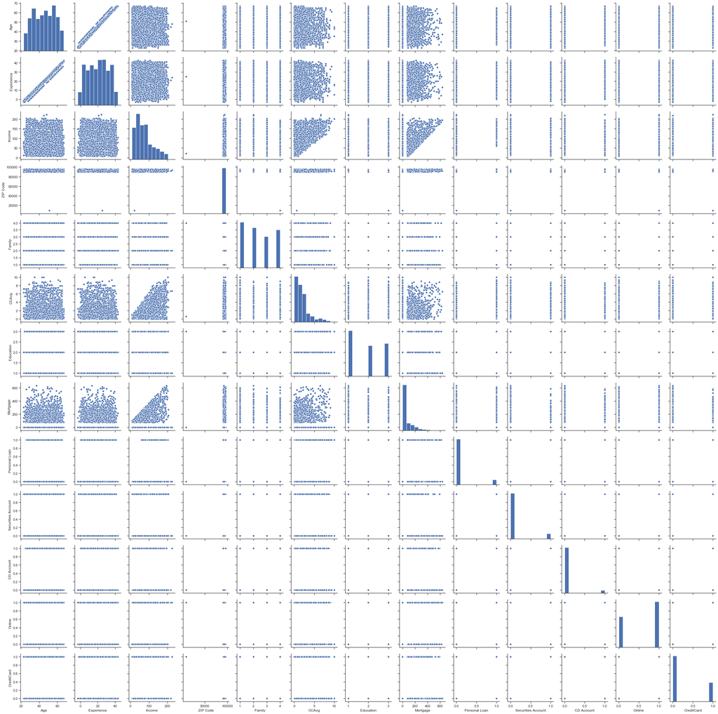

```python
sns.pairplot(banking.iloc[:,1:])
```

#### Data Cleanup

- Experience column contains negative values.
- Apply the following logic to clean up -ve values :
  - For the record with the ID, get the value of Age column
  - For the record with the ID, get the value of Education column
  - Filter the records matching the above criteria from the data frame which has records with positive experience and take the median
  - Apply the median back to the location which had negative experience

```python
# There are 52 rows with -ve experience
banking[banking['Experience'] < 0]['Experience'].count()

#clean the negative variable
dfExp = banking.loc[banking['Experience'] >0]
negExp = banking.Experience < 0
column_name = 'Experience'
# getting the customer ID with negative experience
mylist = banking.loc[negExp]['ID'].tolist()
plist = banking.loc[negExp]['Personal Loan'].sum()

for id in mylist:
    age = banking.loc[np.where(banking['ID']==id)]["Age"].tolist()[0]
    education = banking.loc[np.where(banking['ID']==id)]["Education"].tolist()[0]
    df_filtered = dfExp[(dfExp.Age == age) & (dfExp.Education == education)]
    exp = df_filtered['Experience'].median()
    banking.loc[banking.loc[np.where(banking['ID']==id)].index, 'Experience'] = exp


# checking if there are records with negative experience
banking[banking['Experience'] < 0]['Experience'].count()
```

```
0
```

```python
# There are scenarios where required Age and Education combination does not exist. Removing these rows.
print(banking.isnull().sum())
banking.dropna(inplace=True)
print(banking.isnull().sum())
```

```
ID                     0
Age                    0
Experience            29
Income                 0
ZIP Code               0
Family                 0
CCAvg                  0
Education              0
Mortgage               0
Personal Loan          0
Securities Account     0
CD Account             0
Online                 0
CreditCard             0
dtype: int64
ID                    0
Age                   0
Experience            0
Income                0
ZIP Code              0
Family                0
CCAvg                 0
Education             0
Mortgage              0
Personal Loan         0
Securities Account    0
CD Account            0
Online                0
CreditCard            0
dtype: int64
```

```python
banking.describe().transpose()
```

|  | count | mean | std | min | 25% | 50% | 75% | max |
| --- | --- | --- | --- | --- | --- | --- | --- | --- |
| ID | 4971.0 | 2501.311205 | 1443.553823 | 1.0 | 1254.5 | 2499.0 | 3750.5 | 5000.0 |
| Age | 4971.0 | 45.465299 | 11.375083 | 24.0 | 35.0 | 45.0 | 55.0 | 67.0 |
| Experience | 4971.0 | 20.243211 | 11.359189 | 0.0 | 10.0 | 20.0 | 30.0 | 43.0 |
| Income | 4971.0 | 73.792195 | 46.063254 | 8.0 | 39.0 | 64.0 | 98.0 | 224.0 |
| ZIP Code | 4971.0 | 93154.562663 | 2124.245879 | 9307.0 | 91926.0 | 93437.0 | 94608.0 | 96651.0 |
| Family | 4971.0 | 2.394287 | 1.148282 | 1.0 | 1.0 | 2.0 | 3.0 | 4.0 |
| CCAvg | 4971.0 | 1.934975 | 1.744369 | 0.0 | 0.7 | 1.5 | 2.5 | 10.0 |
| Education | 4971.0 | 1.881513 | 0.840285 | 1.0 | 1.0 | 2.0 | 3.0 | 3.0 |
| Mortgage | 4971.0 | 56.606920 | 101.801630 | 0.0 | 0.0 | 0.0 | 101.0 | 635.0 |
| Personal Loan | 4971.0 | 0.096560 | 0.295387 | 0.0 | 0.0 | 0.0 | 0.0 | 1.0 |
| Securities Account | 4971.0 | 0.104003 | 0.305295 | 0.0 | 0.0 | 0.0 | 0.0 | 1.0 |
| CD Account | 4971.0 | 0.060752 | 0.238900 | 0.0 | 0.0 | 0.0 | 0.0 | 1.0 |
| Online | 4971.0 | 0.596661 | 0.490617 | 0.0 | 0.0 | 1.0 | 1.0 | 1.0 |
| CreditCard | 4971.0 | 0.294307 | 0.455776 | 0.0 | 0.0 | 0.0 | 1.0 | 1.0 |

### Visualize influence of features on Personal Loan

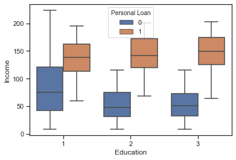

```python
# Influence of income and education on personal loan
sns.boxplot(x='Education',y='Income',hue='Personal Loan',data=banking)
```

```
Income of Non-Loan customers:  66.20863950122467
Income of Loan customers    :  144.74583333333334
```

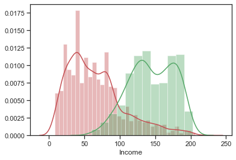

```python
# Further Explore the relationship

# Influence of Income on Personal Loan
sns.distplot( banking[banking['Personal Loan'] == 0]['Income'], color = 'r')
sns.distplot( banking[banking['Personal Loan'] == 1]['Income'], color = 'g')

print('Income of Non-Loan customers: ',banking[banking["Personal Loan"] == 0]['Income'].mean())
print('Income of Loan customers    : ', banking[banking["Personal Loan"] == 1]['Income'].mean())
```

#### Observation

- The box plots show that those with education level 1 have higher incomes.
- But customers who go for personal loans have the same income distribution regardless of the education level.
- People with Personal Loan have Higher Income Levels with the average income being 144K.
- Income is a useful feature for the model. We should target people with Higher Income Levels for Personal Loan.

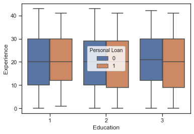

```python
# Influence of Experience and education on personal loan
sns.boxplot(x='Education',y='Experience',hue='Personal Loan',data=banking)
```

#### Observation

- Distribution of people who take loan vs who do not seems to be almost the same.
- Experience level does not seem to have much influence on Personal Loan and can be ignored.

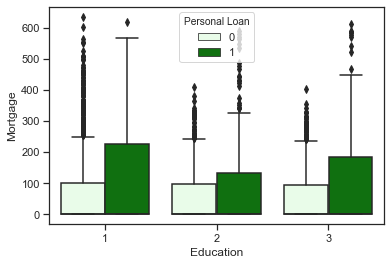

```python
# Influence of Mortgate and Education on Personal Loan

sns.boxplot(x="Education", y='Mortgage', hue="Personal Loan", data=banking,color='green')
```

```python
print('Average Mortgage of Non-Loan customers: ',banking[banking["Personal Loan"] == 0]['Mortgage'].mean())
print('Average Mortgage of Loan customers    : ', banking[banking["Personal Loan"] == 1]['Mortgage'].mean())
```

```
Average Mortgage of Non-Loan customers:  51.87864618125139
Average Mortgage of Loan customers    :  100.84583333333333
```

#### Observation

- Customers who have taken loan have higher mortgages.
- Customers who have taken Personal Loan have an average Mortgage of 100K.
- This is useful information and can be used in the Model .

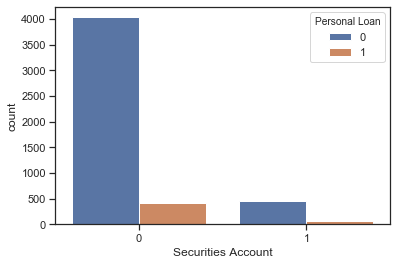

```python
# Influence of Securities Account on Personal Loan
sns.countplot(x="Securities Account", data=banking,hue="Personal Loan")
```

#### Observation

- Majority of people who do not have a Securities Account also do not have a Personal Loan.

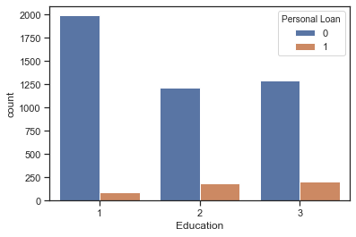

```python
# Influence of Education on Personal Loans
sns.countplot(x='Education',data=banking,hue='Personal Loan')
```

#### Observation

- People with lower Education Level have a Higher Probability of not having a Personal Loan.

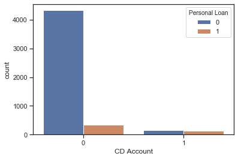

```python
# Influence of CD Account on Personal Loan
sns.countplot(x='CD Account',data=banking,hue='Personal Loan')
```

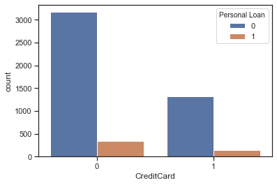

```python
# Influence of Credit Card on Personal Loan
sns.countplot(x='CreditCard',data=banking,hue='Personal Loan')
```

#### Observation

- CreditCard does not seem to have much influence and can be ignored.

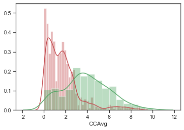

```python
# Influence of CCAvg on Personal Loan
sns.distplot( banking[banking['Personal Loan'] == 0]['CCAvg'], color = 'r')
sns.distplot( banking[banking['Personal Loan'] == 1]['CCAvg'], color = 'g')
```

```python
print('Credit card spending of Non-Loan customers: ',banking[banking["Personal Loan"] == 0]['CCAvg'].mean())
print('Credit card spending of Loan customers    : ', banking[banking["Personal Loan"] == 1]['CCAvg'].mean())
```

```
Credit card spending of Non-Loan customers:  1.724379870852824
Credit card spending of Loan customers    :  3.9053541666666662
```

#### Observation

- The graph show people who have personal loan have a higher credit card average.
- Average credit card spending with an average of 3900 dollar indicates a higher probability of personal loan.
- Lower credit card spending with an average of 1700 dollars is less likely to take a loan.
- This is useful information.

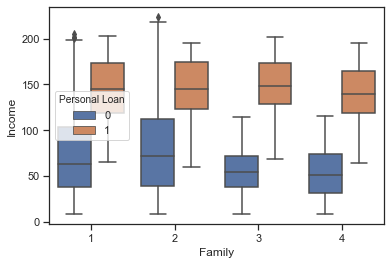

```python
# Influence of Income and Family on Persoanl Loan
sns.boxplot(x=banking.Family,y=banking.Income,hue=banking['Personal Loan'])
```

#### Obervation

- Families who take personal loan tend to have income higher than 100K

### Correlation with Heat Map

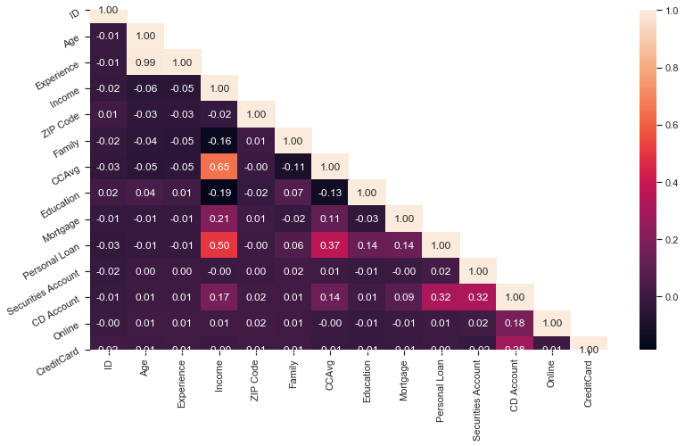

```python
# Correlation with heat map
import matplotlib.pyplot as plt
import seaborn as sns
corr = banking.corr()
sns.set_context("notebook", font_scale=1.0, rc={"lines.linewidth": 2.5})
plt.figure(figsize=(13,7))
# create a mask so we only see the correlation values once
mask = np.zeros_like(corr)
mask[np.triu_indices_from(mask, 1)] = True
a = sns.heatmap(corr,mask=mask, annot=True, fmt='.2f')
rotx = a.set_xticklabels(a.get_xticklabels(), rotation=90)
roty = a.set_yticklabels(a.get_yticklabels(), rotation=30)
```

```python
corr = banking.corr()
corr['Personal Loan'].sort_values(ascending=False)
```

```
Personal Loan         1.000000
Income                0.503631
CCAvg                 0.369321
CD Account            0.316030
Mortgage              0.142083
Education             0.136895
Family                0.062133
Securities Account    0.022487
Online                0.006391
CreditCard            0.002589
ZIP Code             -0.000209
Age                  -0.011458
Experience           -0.011498
ID                   -0.025064
Name: Personal Loan, dtype: float64
```

#### Observation

- Income followed by CCAvg has the highest correlation with personal Loan
- Income and CCAvg is moderately correlated.
- Age and Experience is highly correlated.

#### Applying Models

- Split data into train and test

```python
from sklearn.model_selection import train_test_split
from sklearn.model_selection import cross_val_score
from sklearn.model_selection import KFold
from sklearn.metrics import accuracy_score
from sklearn import metrics

from sklearn.linear_model import LogisticRegression
from sklearn.neighbors import KNeighborsClassifier
from sklearn.naive_bayes import GaussianNB

# 30% of the data will be used for testing
test_size= 0.30
seed = 100


# X and y features
y1 = banking['Personal Loan']
X1 = banking.drop(['ID', 'Personal Loan', 'Experience', 'Online', 'CreditCard', 'ZIP Code', 'Age'], axis =1)

x_train1, x_test1, y_train1, y_test1 = train_test_split(X1, y1, test_size=test_size, random_state=seed)
```

### Logistic Regression

```python
# Logistic Regression

LR = LogisticRegression(solver='lbfgs', max_iter=1000)
# fit model

LR.fit(x_train1, y_train1)
```

```
LogisticRegression(C=1.0, class_weight=None, dual=False, fit_intercept=True,
                   intercept_scaling=1, l1_ratio=None, max_iter=1000,
                   multi_class='warn', n_jobs=None, penalty='l2',
                   random_state=None, solver='lbfgs', tol=0.0001, verbose=0,
                   warm_start=False)
```

#### Get the Coefficient for each feature.

```python
name = X1.columns
coef = LR.coef_[0]

print(pd.DataFrame([name,coef],index = ['Name','Coef']).transpose())
```

```
                 Name         Coef
0              Income    0.0549195
1              Family     0.786778
2               CCAvg     0.106777
3           Education      1.58149
4            Mortgage  0.000545907
5  Securities Account    -0.541625
6          CD Account      2.53314
```

#### Observation

- CD Account has the largest coeff followed by Education.

### Use the Model to predict on x_test

```python
# predict with model
y_pred = LR.predict(x_test1)
```

```python
metrics.accuracy_score(y_test1,y_pred)
```

```
0.9477211796246648
```

```python
banking['Personal Loan'].value_counts()
```

```
0    4491
1     480
Name: Personal Loan, dtype: int64
```

#### Accuracy Score

Accuracy score is the percentage of correct predictions out of all predictions made.

#### Confusion Matrix

```
[[1328   24]
 [  54   86]]
```

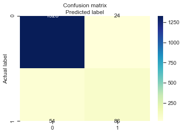

```python
cm = metrics.confusion_matrix(y_test1,y_pred)
print(cm)

class_names=[0,1] # name  of classes
fig, ax = plt.subplots()
tick_marks = np.arange(len(class_names))
plt.xticks(tick_marks, class_names)
plt.yticks(tick_marks, class_names)
# create heatmap
# annot_kws = {"ha": 'center',"va": 'top'}
sns.heatmap(pd.DataFrame(cm), annot=True, cmap="YlGnBu" ,fmt='d')
ax.xaxis.set_label_position("top")
#plt.tight_layout()
plt.title('Confusion matrix', y=1.1)
plt.ylabel('Actual label')
plt.xlabel('Predicted label')
plt.show()
```

#### Observation

- Out of 1352 No it predicted 1328 correctly (True Negative)
- Out of 140 instances of Yes it correctly predicted 86.

A problem revealed by this confusion matrix is that the dataset is highly unbalanced, with nearly all client actually do not have a Personal Loan. This infers that the accuracy score is biased, and further evaluation should be carried out to determine the accuracy of logistic regression model.

#### ROC AUC

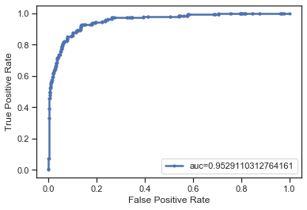

```python
# Probability estimates
from sklearn.metrics import roc_curve
from sklearn.metrics import roc_auc_score
from sklearn.metrics import precision_recall_curve
from sklearn.metrics import f1_score


# Keep Probabilities for the positive Outcomes only
y_pred_proba = LR.predict_proba(x_test1)[:,1]

auc = roc_auc_score(y_test1, y_pred_proba)
fpr, tpr, _ = roc_curve(y_test1, y_pred_proba)
plt.plot(fpr, tpr, marker='.', label="auc="+str(auc))
# axis labels
plt.xlabel('False Positive Rate')
plt.ylabel('True Positive Rate')
# show the legend
plt.legend()
# show the plot
plt.show()
```

#### Precision-Recall Curve

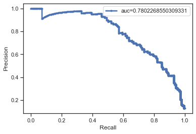

```
f1=0.688 auc=0.780
```

```python
from sklearn.metrics import auc

precision, recall, _ = precision_recall_curve(y_test1, y_pred_proba)

f1= f1_score(y_test1, y_pred)

auc = auc(recall, precision)
plt.plot(recall, precision, marker='.', label="auc="+str(auc))
# axis labels
plt.xlabel('Recall')
plt.ylabel('Precision')
# show the legend
plt.legend()
# show the plot
plt.show()
print('f1=%.3f auc=%.3f' % (f1, auc))
```

#### When to Use ROC vs. Precision-Recall Curves?

- ROC curves should be used when there are roughly equal numbers of observations for each class.
- Precision-Recall curves should be used when there is a moderate to large class imbalance.

The reason for this recommendation is that ROC curves present an optimistic picture of the model on datasets with a class imbalance.

#### Log Loss

```python
metrics.log_loss(y_test1,y_pred)
```

```
1.8056593492904551
```

#### Classification Report

```python
print(metrics.classification_report(y_test1, y_pred))
```

```
              precision    recall  f1-score   support

           0       0.96      0.98      0.97      1352
           1       0.78      0.61      0.69       140

    accuracy                           0.95      1492
   macro avg       0.87      0.80      0.83      1492
weighted avg       0.94      0.95      0.94      1492
```

Classification report shows the precision, recall, F1 and support scores for the LR classification model.

- Precision of 0 (the client does NOT have Personal Loan) represents that for all instances predicted as no Personal Loan, the percentage of clients that actually do not have Loan is 96%.
- Recall is the ability of a classifier to find all positive instances. Recall of 0 indicates that for all clients that actually do not have Personal Loan, the model predicts 98% correctly that they would not have the Loan.
- Precision of 1 (the client have a Perosnal Loan) is 78%.
- Recall of 1 is 61% which mean that the model predicts 61% times correctly that the person would have a Personal Loan.
- In general, the report shows that LR model has great predictive power to identify the customers who would not have a Personal Loan.

**Selecting a model with higher Recall value for Class 1 (Accepting Personal Loan) is more important than a model with higher Precision since its better to reach out to a larger audience than losing out on a likely candidate.**

### Naive Bayes

```python
naive_model = GaussianNB()
naive_model.fit(x_train1, y_train1)

y_pred = naive_model.predict(x_test1)

metrics.accuracy_score(y_test1,y_pred)
```

```
0.8793565683646113
```

NB has an accuracy at par with the baseline of "No Personal Loan" everytime.

#### Cofusion Matrix

```
[[1230  122]
 [  58   82]]
```

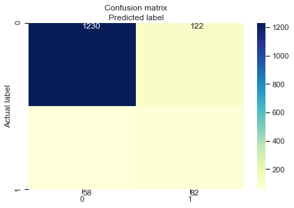

```python
cm = metrics.confusion_matrix(y_test1,y_pred)
print(cm)

class_names=[0,1] # name  of classes
fig, ax = plt.subplots()
tick_marks = np.arange(len(class_names))
plt.xticks(tick_marks, class_names)
plt.yticks(tick_marks, class_names)
# create heatmap
annot_kws = {"ha": 'left',"va": 'top'}
sns.heatmap(pd.DataFrame(cm), annot=True, annot_kws=annot_kws, cmap="YlGnBu" ,fmt='g')
ax.xaxis.set_label_position("top")
plt.tight_layout()
plt.title('Confusion matrix', y=1.1)
plt.ylabel('Actual label')
plt.xlabel('Predicted label')
plt.show()
```

#### Classification Report

```python
print(metrics.classification_report(y_test1, y_pred))
```

```
              precision    recall  f1-score   support

           0       0.95      0.91      0.93      1352
           1       0.40      0.59      0.48       140

    accuracy                           0.88      1492
   macro avg       0.68      0.75      0.70      1492
weighted avg       0.90      0.88      0.89      1492
```

- Precision of 0 (the client said no) represents that for all instances predicted as no subscription, the percentage of clients that actually said no is 95%.
- Recall is the ability of a classifier to find all positive instances. Recall of 0 indicates that for all clients that actually said no, the model predicts 91% correctly that they would decline the offer.

### KNN ( K - Nearest Neighbour )

```python
knn = KNeighborsClassifier(n_neighbors= 21 , weights = 'uniform', metric='euclidean')
knn.fit(x_train1, y_train1)
y_pred = knn.predict(x_test1)

acc = accuracy_score(y_test1,y_pred)
print(acc)
```

```
0.9195710455764075
```

```
[[1331   21]
 [  99   41]]
```

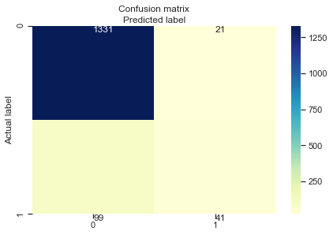

```python
cm = metrics.confusion_matrix(y_test1,y_pred)
print(cm)

class_names=[0,1] # name  of classes
fig, ax = plt.subplots()
tick_marks = np.arange(len(class_names))
plt.xticks(tick_marks, class_names)
plt.yticks(tick_marks, class_names)
# create heatmap
annot_kws = {"ha": 'left',"va": 'top'}
sns.heatmap(pd.DataFrame(cm), annot=True, annot_kws=annot_kws, cmap="YlGnBu" ,fmt='g')
ax.xaxis.set_label_position("top")
plt.tight_layout()
plt.title('Confusion matrix', y=1.1)
plt.ylabel('Actual label')
plt.xlabel('Predicted label')
plt.show()
```

```python
print(metrics.classification_report(y_test1, y_pred))
```

```
              precision    recall  f1-score   support

           0       0.93      0.98      0.96      1352
           1       0.66      0.29      0.41       140

    accuracy                           0.92      1492
   macro avg       0.80      0.64      0.68      1492
weighted avg       0.91      0.92      0.91      1492
```

#### Observation

- KNN performs better than Naive Bayes and equal to LR in Recall of Class 0.
- However, KNN behaves the worst amongst all the previous Models for predicting people who would opt for the Personal Loan.

### Compare classification algorithms

Three different classification algorithms (Logistic Regression, K-Neighbors Classifier, and Gaussian NB) are run on the dataset and identify the best performing one.

```python
models = []
models.append(('LR', LogisticRegression(solver='lbfgs', max_iter=1000)))
models.append(('KNN', KNeighborsClassifier(n_neighbors= 21 , weights = 'uniform', metric='euclidean')))
models.append(('NB', GaussianNB()))
```

```python
results_c = []
names_c = []

for name, model in models:
    # define how to split off validation data ('kfold' how many folds)
    kfold = KFold(n_splits=10, random_state=seed)
    # train the model
    cv_results = cross_val_score(model, x_train1, y_train1, cv=kfold, scoring='accuracy', error_score='raise')
    results_c.append(cv_results)
    names_c.append(name)
    msg = "%s: %f (%f)" % (name, cv_results.mean(), cv_results.std())
    print(msg)
```

```
LR: 0.944524 (0.008238)
KNN: 0.910891 (0.012486)
NB: 0.884450 (0.011334)
```

#### Logistic regression is the best performing model.

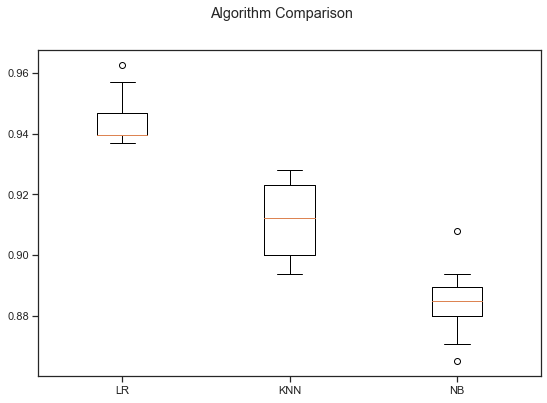

```python
# Plot results
fig = plt.figure(figsize=(9,6))
ax = fig.add_subplot(111)
plt.boxplot(results_c)

fig.suptitle('Algorithm Comparison')
ax.set_xticklabels(names_c)
plt.show()
```

Among all algorithms, logistic regression achieved an accuracy of about 95%, suggesting a high level of strength of this model to classify the customer response given all the defined customer features.

The main objective of this project is to predict the likelihood of a liability customer buying personal loans, which was successfully met through data analysis, visualization and analytical model building. A target customer profile was established while classification and regression models were built to predict the likelihood of a liability customer buying personal loan.

## Conclusion:

According to previous analysis, a target customer profile can be established. The most likely customers possess these features:

- Feature 1: Income > 100K with an average of 144K
- Feature 2: CC Avg > 3000 with an average of 3900
- Feature 3: Has a CD Account
- Feature 4: Average Mortgage of 100K

By applying logistic regression algorithm, classification model was successfully built.

**Selecting a model with higher Recall value for Class 1 (Accepting Personal Loan) is more important than a model with higher Precision since its better to reach out to a larger audience than losing out on a likely candidate.**